# Risk Factor Analysis

## Outcome Variable

**Outcome Variable:** haz

## Predictor Variables

**Intervention Variable:** exclfeed3

**Adjustment Set:**

- arm
- sex
- W_mage
- meducyrs
- feducyrs
- hhwealth_quart
- hfoodsec
- W_mhtcm
- vagbrth
- W_gagebrth
- W_birthwt
- W_birthlen
- W_nrooms
- W_nchldlt5
- month
- brthmon
- W_parity
- impfloor
- impsan
- safeh20
- delta_W_mage
- delta_meducyrs
- delta_feducyrs
- delta_hhwealth_quart
- delta_hfoodsec
- delta_W_mhtcm
- delta_vagbrth
- delta_W_gagebrth
- delta_W_birthwt
- delta_W_birthlen
- delta_W_nrooms
- delta_W_nchldlt5
- delta_month
- delta_brthmon
- delta_W_parity
- delta_impfloor
- delta_impsan
- delta_safeh20

## Stratifying Variables

The analysis was stratified on these variable(s):

- agecat
- studyid
- country

## Data Summary

| agecat | studyid | country | exclfeed3 | n_cell | n |
| --- | --- | --- | --- | --- | --- |
| Birth | ki0047075b-MAL-ED | BANGLADESH | 1 | 173 | 240 |
| Birth | ki0047075b-MAL-ED | BANGLADESH | 0 | 67 | 240 |
| Birth | ki0047075b-MAL-ED | BRAZIL | 1 | 67 | 185 |
| Birth | ki0047075b-MAL-ED | BRAZIL | 0 | 118 | 185 |
| Birth | ki0047075b-MAL-ED | INDIA | 1 | 123 | 196 |
| Birth | ki0047075b-MAL-ED | INDIA | 0 | 73 | 196 |
| Birth | ki0047075b-MAL-ED | NEPAL | 1 | 61 | 171 |
| Birth | ki0047075b-MAL-ED | NEPAL | 0 | 110 | 171 |
| Birth | ki0047075b-MAL-ED | PERU | 1 | 67 | 272 |
| Birth | ki0047075b-MAL-ED | PERU | 0 | 205 | 272 |
| Birth | ki0047075b-MAL-ED | SOUTH AFRICA | 1 | 32 | 233 |
| Birth | ki0047075b-MAL-ED | SOUTH AFRICA | 0 | 201 | 233 |
| Birth | ki0047075b-MAL-ED | TANZANIA, UNITED REPUBLIC OF | 1 | 39 | 119 |
| Birth | ki0047075b-MAL-ED | TANZANIA, UNITED REPUBLIC OF | 0 | 80 | 119 |
| Birth | ki1000108-CMC-V-BCS-2002 | INDIA | 1 | 4 | 4 |
| Birth | ki1000108-CMC-V-BCS-2002 | INDIA | 0 | 0 | 4 |
| Birth | ki1000108-IRC | INDIA | 1 | 0 | 10 |
| Birth | ki1000108-IRC | INDIA | 0 | 10 | 10 |
| Birth | ki1000109-EE | PAKISTAN | 1 | 2 | 2 |
| Birth | ki1000109-EE | PAKISTAN | 0 | 0 | 2 |
| Birth | ki1000304b-SAS-CompFeed | INDIA | 1 | 48 | 50 |
| Birth | ki1000304b-SAS-CompFeed | INDIA | 0 | 2 | 50 |
| Birth | ki1101329-Keneba | GAMBIA | 1 | 1196 | 1354 |
| Birth | ki1101329-Keneba | GAMBIA | 0 | 158 | 1354 |
| Birth | kiGH5241-JiVitA-3 | BANGLADESH | 1 | 16824 | 18710 |
| Birth | kiGH5241-JiVitA-3 | BANGLADESH | 0 | 1886 | 18710 |
| Birth | kiGH5241-JiVitA-4 | BANGLADESH | 1 | 37 | 40 |
| Birth | kiGH5241-JiVitA-4 | BANGLADESH | 0 | 3 | 40 |
| 6 months | ki0047075b-MAL-ED | BANGLADESH | 1 | 172 | 237 |
| 6 months | ki0047075b-MAL-ED | BANGLADESH | 0 | 65 | 237 |

[output cut: 58 more lines]

The following strata were considered:

- agecat: 24 months, studyid: ki0047075b-MAL-ED, country: BANGLADESH
- agecat: 24 months, studyid: ki0047075b-MAL-ED, country: BRAZIL
- agecat: 24 months, studyid: ki0047075b-MAL-ED, country: INDIA
- agecat: 24 months, studyid: ki0047075b-MAL-ED, country: NEPAL
- agecat: 24 months, studyid: ki0047075b-MAL-ED, country: PERU
- agecat: 24 months, studyid: ki0047075b-MAL-ED, country: SOUTH AFRICA
- agecat: 24 months, studyid: ki0047075b-MAL-ED, country: TANZANIA, UNITED REPUBLIC OF
- agecat: 24 months, studyid: ki1000108-CMC-V-BCS-2002, country: INDIA
- agecat: 24 months, studyid: ki1000108-IRC, country: INDIA
- agecat: 24 months, studyid: ki1017093b-PROVIDE, country: BANGLADESH
- agecat: 24 months, studyid: ki1101329-Keneba, country: GAMBIA
- agecat: 24 months, studyid: ki1113344-GMS-Nepal, country: NEPAL
- agecat: 24 months, studyid: kiGH5241-JiVitA-3, country: BANGLADESH
- agecat: 24 months, studyid: kiGH5241-JiVitA-4, country: BANGLADESH
- agecat: 6 months, studyid: ki0047075b-MAL-ED, country: BANGLADESH
- agecat: 6 months, studyid: ki0047075b-MAL-ED, country: BRAZIL
- agecat: 6 months, studyid: ki0047075b-MAL-ED, country: INDIA
- agecat: 6 months, studyid: ki0047075b-MAL-ED, country: NEPAL
- agecat: 6 months, studyid: ki0047075b-MAL-ED, country: PERU
- agecat: 6 months, studyid: ki0047075b-MAL-ED, country: SOUTH AFRICA
- agecat: 6 months, studyid: ki0047075b-MAL-ED, country: TANZANIA, UNITED REPUBLIC OF
- agecat: 6 months, studyid: ki1000108-CMC-V-BCS-2002, country: INDIA
- agecat: 6 months, studyid: ki1000108-IRC, country: INDIA
- agecat: 6 months, studyid: ki1000109-EE, country: PAKISTAN
- agecat: 6 months, studyid: ki1000304b-SAS-CompFeed, country: INDIA
- agecat: 6 months, studyid: ki1017093b-PROVIDE, country: BANGLADESH
- agecat: 6 months, studyid: ki1101329-Keneba, country: GAMBIA
- agecat: 6 months, studyid: ki1113344-GMS-Nepal, country: NEPAL
- agecat: 6 months, studyid: kiGH5241-JiVitA-3, country: BANGLADESH
- agecat: 6 months, studyid: kiGH5241-JiVitA-4, country: BANGLADESH
- agecat: Birth, studyid: ki0047075b-MAL-ED, country: BANGLADESH
- agecat: Birth, studyid: ki0047075b-MAL-ED, country: BRAZIL
- agecat: Birth, studyid: ki0047075b-MAL-ED, country: INDIA
- agecat: Birth, studyid: ki0047075b-MAL-ED, country: NEPAL
- agecat: Birth, studyid: ki0047075b-MAL-ED, country: PERU
- agecat: Birth, studyid: ki0047075b-MAL-ED, country: SOUTH AFRICA
- agecat: Birth, studyid: ki0047075b-MAL-ED, country: TANZANIA, UNITED REPUBLIC OF
- agecat: Birth, studyid: ki1000108-CMC-V-BCS-2002, country: INDIA
- agecat: Birth, studyid: ki1000108-IRC, country: INDIA
- agecat: Birth, studyid: ki1000109-EE, country: PAKISTAN
- agecat: Birth, studyid: ki1000304b-SAS-CompFeed, country: INDIA
- agecat: Birth, studyid: ki1101329-Keneba, country: GAMBIA
- agecat: Birth, studyid: kiGH5241-JiVitA-3, country: BANGLADESH
- agecat: Birth, studyid: kiGH5241-JiVitA-4, country: BANGLADESH

### Dropped Strata

Some strata were dropped due to rare outcomes:

- agecat: Birth, studyid: ki1000108-CMC-V-BCS-2002, country: INDIA
- agecat: Birth, studyid: ki1000108-IRC, country: INDIA
- agecat: Birth, studyid: ki1000109-EE, country: PAKISTAN
- agecat: Birth, studyid: ki1000304b-SAS-CompFeed, country: INDIA
- agecat: Birth, studyid: kiGH5241-JiVitA-4, country: BANGLADESH
- agecat: 6 months, studyid: ki1000108-CMC-V-BCS-2002, country: INDIA
- agecat: 6 months, studyid: ki1000108-IRC, country: INDIA
- agecat: 24 months, studyid: ki1000108-CMC-V-BCS-2002, country: INDIA
- agecat: 24 months, studyid: ki1000108-IRC, country: INDIA

## Methods Detail

We’re interested in the causal parameters $E[Y_a]$ for all values of $a \in \mathcal{A}$. These parameters represent the mean outcome if, possibly contrary to fact, we intervened to set all units to have $A=a$. Under the randomization and positivity assumptions, these are identified by the statistical parameters $\psi_a=E_W[E_{Y|A,W}(Y|A=a,W)]$. In addition, we’re interested in the mean of $Y$, $E[Y]$ under no intervention (the observed mean). We will estimate these parameters by using SuperLearner to fit the relevant likelihood factors – $E_{Y|A,W}(Y|A=a,W)$ and $p(A=a|W)$, and then updating our likelihood fit using a joint TMLE.

For unadjusted analyses ($W=\{\}$), initial likelihoods were estimated using Lrnr_glm to estimate the simple $E(Y|A)$ and Lrnr_mean to estimate $p(A)$. For adjusted analyses, a small library containing Lrnr_glmnet, Lrnr_xgboost, and Lrnr_mean was used.

Having estimated these parameters, we will then use the delta method to estimate relative risks and attributable risks relative to a prespecified baseline level of $A$.

# Results Detail

## Results Plots

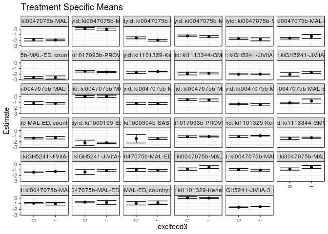

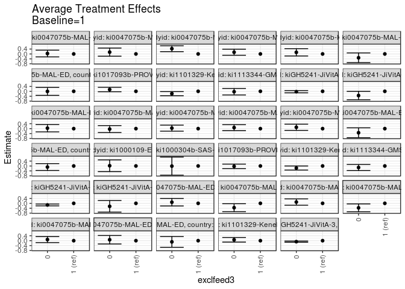

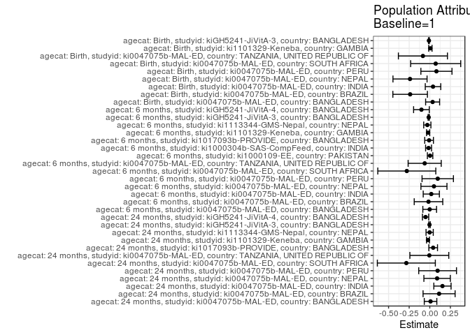

## Results Table

### Parameter: TSM

| agecat | studyid | country | intervention_level | baseline_level | estimate | ci_lower | ci_upper |
| --- | --- | --- | --- | --- | --- | --- | --- |
| Birth | ki0047075b-MAL-ED | BANGLADESH | 1 | NA | -1.0840857 | -1.2300035 | -0.9381679 |
| Birth | ki0047075b-MAL-ED | BANGLADESH | 0 | NA | -0.9917512 | -1.2597180 | -0.7237845 |
| Birth | ki0047075b-MAL-ED | BRAZIL | 1 | NA | -0.4968481 | -0.7414294 | -0.2522667 |
| Birth | ki0047075b-MAL-ED | BRAZIL | 0 | NA | -0.8529880 | -1.0626013 | -0.6433747 |
| Birth | ki0047075b-MAL-ED | INDIA | 1 | NA | -1.0490665 | -1.2238632 | -0.8742697 |
| Birth | ki0047075b-MAL-ED | INDIA | 0 | NA | -0.9442176 | -1.1550023 | -0.7334330 |
| Birth | ki0047075b-MAL-ED | NEPAL | 1 | NA | -0.4729851 | -0.7191943 | -0.2267759 |
| Birth | ki0047075b-MAL-ED | NEPAL | 0 | NA | -0.8396561 | -1.0416710 | -0.6376411 |
| Birth | ki0047075b-MAL-ED | PERU | 1 | NA | -1.0067556 | -1.2415386 | -0.7719725 |
| Birth | ki0047075b-MAL-ED | PERU | 0 | NA | -0.9160580 | -1.0346357 | -0.7974804 |
| Birth | ki0047075b-MAL-ED | SOUTH AFRICA | 1 | NA | -0.7824784 | -1.1104747 | -0.4544821 |
| Birth | ki0047075b-MAL-ED | SOUTH AFRICA | 0 | NA | -0.7065813 | -0.8438556 | -0.5693070 |
| Birth | ki0047075b-MAL-ED | TANZANIA, UNITED REPUBLIC OF | 1 | NA | -0.8372478 | -1.1614868 | -0.5130087 |
| Birth | ki0047075b-MAL-ED | TANZANIA, UNITED REPUBLIC OF | 0 | NA | -0.9350028 | -1.2284612 | -0.6415445 |
| Birth | ki1101329-Keneba | GAMBIA | 1 | NA | 0.0066000 | -0.0663266 | 0.0795266 |
| Birth | ki1101329-Keneba | GAMBIA | 0 | NA | 0.0785353 | -0.1009027 | 0.2579733 |
| Birth | kiGH5241-JiVitA-3 | BANGLADESH | 1 | NA | -1.5353289 | -1.5551312 | -1.5155267 |
| Birth | kiGH5241-JiVitA-3 | BANGLADESH | 0 | NA | -1.6146866 | -1.6629611 | -1.5664122 |
| 6 months | ki0047075b-MAL-ED | BANGLADESH | 1 | NA | -1.1998787 | -1.3280104 | -1.0717470 |
| 6 months | ki0047075b-MAL-ED | BANGLADESH | 0 | NA | -1.1628553 | -1.4339094 | -0.8918012 |
| 6 months | ki0047075b-MAL-ED | BRAZIL | 1 | NA | 0.0667113 | -0.1453247 | 0.2787474 |
| 6 months | ki0047075b-MAL-ED | BRAZIL | 0 | NA | 0.0304883 | -0.1603264 | 0.2213031 |
| 6 months | ki0047075b-MAL-ED | INDIA | 1 | NA | -1.2292514 | -1.3814013 | -1.0771015 |
| 6 months | ki0047075b-MAL-ED | INDIA | 0 | NA | -1.1870433 | -1.3808243 | -0.9932624 |
| 6 months | ki0047075b-MAL-ED | NEPAL | 1 | NA | -0.6062186 | -0.8082695 | -0.4041678 |
| 6 months | ki0047075b-MAL-ED | NEPAL | 0 | NA | -0.5223271 | -0.6572898 | -0.3873643 |
| 6 months | ki0047075b-MAL-ED | PERU | 1 | NA | -1.4193256 | -1.6403744 | -1.1982769 |
| 6 months | ki0047075b-MAL-ED | PERU | 0 | NA | -1.3079119 | -1.4309273 | -1.1848965 |
| 6 months | ki0047075b-MAL-ED | SOUTH AFRICA | 1 | NA | -0.7851111 | -1.1634950 | -0.4067272 |
| 6 months | ki0047075b-MAL-ED | SOUTH AFRICA | 0 | NA | -1.1200695 | -1.2570071 | -0.9831319 |
| 6 months | ki0047075b-MAL-ED | TANZANIA, UNITED REPUBLIC OF | 1 | NA | -1.2898246 | -1.5307006 | -1.0489486 |
| 6 months | ki0047075b-MAL-ED | TANZANIA, UNITED REPUBLIC OF | 0 | NA | -1.3778024 | -1.5231731 | -1.2324318 |
| 6 months | ki1000109-EE | PAKISTAN | 1 | NA | -2.2094607 | -2.3367683 | -2.0821532 |
| 6 months | ki1000109-EE | PAKISTAN | 0 | NA | -2.1890863 | -2.6488889 | -1.7292838 |
| 6 months | ki1000304b-SAS-CompFeed | INDIA | 1 | NA | -1.4549959 | -1.6008850 | -1.3091069 |
| 6 months | ki1000304b-SAS-CompFeed | INDIA | 0 | NA | -1.4654856 | -2.2428805 | -0.6880907 |
| 6 months | ki1017093b-PROVIDE | BANGLADESH | 1 | NA | -1.0785688 | -1.1645978 | -0.9925399 |
| 6 months | ki1017093b-PROVIDE | BANGLADESH | 0 | NA | -1.1079312 | -1.2694045 | -0.9464579 |
| 6 months | ki1101329-Keneba | GAMBIA | 1 | NA | -0.9290273 | -0.9830796 | -0.8749750 |
| 6 months | ki1101329-Keneba | GAMBIA | 0 | NA | -1.0941215 | -1.2509661 | -0.9372770 |
| 6 months | ki1113344-GMS-Nepal | NEPAL | 1 | NA | -1.2935247 | -1.3865848 | -1.2004646 |
| 6 months | ki1113344-GMS-Nepal | NEPAL | 0 | NA | -1.4184155 | -1.6489129 | -1.1879182 |
| 6 months | kiGH5241-JiVitA-3 | BANGLADESH | 1 | NA | -1.2925663 | -1.3159707 | -1.2691618 |
| 6 months | kiGH5241-JiVitA-3 | BANGLADESH | 0 | NA | -1.4241997 | -1.4978220 | -1.3505774 |
| 6 months | kiGH5241-JiVitA-4 | BANGLADESH | 1 | NA | -1.1327438 | -1.3172969 | -0.9481907 |
| 6 months | kiGH5241-JiVitA-4 | BANGLADESH | 0 | NA | -1.3763199 | -1.7994932 | -0.9531465 |
| 24 months | ki0047075b-MAL-ED | BANGLADESH | 1 | NA | -1.9483901 | -2.1019873 | -1.7947930 |
| 24 months | ki0047075b-MAL-ED | BANGLADESH | 0 | NA | -1.9127973 | -2.1406298 | -1.6849648 |
| 24 months | ki0047075b-MAL-ED | BRAZIL | 1 | NA | -0.0709541 | -0.3219767 | 0.1800686 |
| 24 months | ki0047075b-MAL-ED | BRAZIL | 0 | NA | 0.0784777 | -0.1449435 | 0.3018988 |
| 24 months | ki0047075b-MAL-ED | INDIA | 1 | NA | -1.9970943 | -2.1595789 | -1.8346096 |
| 24 months | ki0047075b-MAL-ED | INDIA | 0 | NA | -1.5684744 | -1.7517864 | -1.3851624 |
| 24 months | ki0047075b-MAL-ED | NEPAL | 1 | NA | -1.3581846 | -1.5530042 | -1.1633651 |
| 24 months | ki0047075b-MAL-ED | NEPAL | 0 | NA | -1.2166124 | -1.3699312 | -1.0632937 |
| 24 months | ki0047075b-MAL-ED | PERU | 1 | NA | -1.8388594 | -2.1156315 | -1.5620873 |
| 24 months | ki0047075b-MAL-ED | PERU | 0 | NA | -1.7071906 | -1.8351998 | -1.5791814 |
| 24 months | ki0047075b-MAL-ED | SOUTH AFRICA | 1 | NA | -1.3269088 | -1.6913438 | -0.9624738 |
| 24 months | ki0047075b-MAL-ED | SOUTH AFRICA | 0 | NA | -1.6382674 | -1.7869185 | -1.4896164 |
| 24 months | ki0047075b-MAL-ED | TANZANIA, UNITED REPUBLIC OF | 1 | NA | -2.6103779 | -2.8947754 | -2.3259805 |
| 24 months | ki0047075b-MAL-ED | TANZANIA, UNITED REPUBLIC OF | 0 | NA | -2.6185118 | -2.7732343 | -2.4637892 |
| 24 months | ki1017093b-PROVIDE | BANGLADESH | 1 | NA | -1.6270467 | -1.7244786 | -1.5296148 |
| 24 months | ki1017093b-PROVIDE | BANGLADESH | 0 | NA | -1.4839872 | -1.6389211 | -1.3290534 |
| 24 months | ki1101329-Keneba | GAMBIA | 1 | NA | -1.5584842 | -1.6152675 | -1.5017009 |
| 24 months | ki1101329-Keneba | GAMBIA | 0 | NA | -1.7511114 | -1.9130922 | -1.5891306 |
| 24 months | ki1113344-GMS-Nepal | NEPAL | 1 | NA | -1.8770860 | -1.9758883 | -1.7782838 |
| 24 months | ki1113344-GMS-Nepal | NEPAL | 0 | NA | -1.9110210 | -2.1536921 | -1.6683499 |
| 24 months | kiGH5241-JiVitA-3 | BANGLADESH | 1 | NA | -2.0077207 | -2.0366667 | -1.9787746 |
| 24 months | kiGH5241-JiVitA-3 | BANGLADESH | 0 | NA | -2.0415688 | -2.1307484 | -1.9523891 |
| 24 months | kiGH5241-JiVitA-4 | BANGLADESH | 1 | NA | -1.7158822 | -1.8594694 | -1.5722951 |
| 24 months | kiGH5241-JiVitA-4 | BANGLADESH | 0 | NA | -2.0614749 | -2.3746682 | -1.7482816 |

### Parameter: E(Y)

| agecat | studyid | country | intervention_level | baseline_level | estimate | ci_lower | ci_upper |
| --- | --- | --- | --- | --- | --- | --- | --- |
| Birth | ki0047075b-MAL-ED | BANGLADESH | NA | NA | -1.0497083 | -1.1780996 | -0.9213171 |
| Birth | ki0047075b-MAL-ED | BRAZIL | NA | NA | -0.7350811 | -0.8943683 | -0.5757938 |
| Birth | ki0047075b-MAL-ED | INDIA | NA | NA | -1.0098469 | -1.1519586 | -0.8677353 |
| Birth | ki0047075b-MAL-ED | NEPAL | NA | NA | -0.7128070 | -0.8704934 | -0.5551207 |
| Birth | ki0047075b-MAL-ED | PERU | NA | NA | -0.9261397 | -1.0389037 | -0.8133757 |
| Birth | ki0047075b-MAL-ED | SOUTH AFRICA | NA | NA | -0.7108584 | -0.8390511 | -0.5826657 |
| Birth | ki0047075b-MAL-ED | TANZANIA, UNITED REPUBLIC OF | NA | NA | -0.9205882 | -1.1394357 | -0.7017408 |
| Birth | ki1101329-Keneba | GAMBIA | NA | NA | 0.0135081 | -0.0559902 | 0.0830065 |
| Birth | kiGH5241-JiVitA-3 | BANGLADESH | NA | NA | -1.5457493 | -1.5650991 | -1.5263996 |
| 6 months | ki0047075b-MAL-ED | BANGLADESH | NA | NA | -1.2009705 | -1.3199485 | -1.0819924 |
| 6 months | ki0047075b-MAL-ED | BRAZIL | NA | NA | 0.0510207 | -0.0930194 | 0.1950608 |
| 6 months | ki0047075b-MAL-ED | INDIA | NA | NA | -1.2109514 | -1.3300505 | -1.0918522 |
| 6 months | ki0047075b-MAL-ED | NEPAL | NA | NA | -0.5557940 | -0.6681063 | -0.4434817 |
| 6 months | ki0047075b-MAL-ED | PERU | NA | NA | -1.3229136 | -1.4307207 | -1.2151065 |
| 6 months | ki0047075b-MAL-ED | SOUTH AFRICA | NA | NA | -1.0640356 | -1.1937663 | -0.9343049 |
| 6 months | ki0047075b-MAL-ED | TANZANIA, UNITED REPUBLIC OF | NA | NA | -1.3516458 | -1.4765824 | -1.2267092 |
| 6 months | ki1000109-EE | PAKISTAN | NA | NA | -2.2056604 | -2.3285064 | -2.0828144 |
| 6 months | ki1000304b-SAS-CompFeed | INDIA | NA | NA | -1.4697236 | -1.6333919 | -1.3060553 |
| 6 months | ki1017093b-PROVIDE | BANGLADESH | NA | NA | -1.0871041 | -1.1635539 | -1.0106543 |
| 6 months | ki1101329-Keneba | GAMBIA | NA | NA | -0.9489317 | -1.0001696 | -0.8976937 |
| 6 months | ki1113344-GMS-Nepal | NEPAL | NA | NA | -1.3235298 | -1.4103807 | -1.2366790 |
| 6 months | kiGH5241-JiVitA-3 | BANGLADESH | NA | NA | -1.3060279 | -1.3292905 | -1.2827653 |
| 6 months | kiGH5241-JiVitA-4 | BANGLADESH | NA | NA | -1.2339326 | -1.4137041 | -1.0541611 |
| 24 months | ki0047075b-MAL-ED | BANGLADESH | NA | NA | -1.9391587 | -2.0665449 | -1.8117724 |
| 24 months | ki0047075b-MAL-ED | BRAZIL | NA | NA | 0.0418343 | -0.1253834 | 0.2090521 |
| 24 months | ki0047075b-MAL-ED | INDIA | NA | NA | -1.8433556 | -1.9704665 | -1.7162446 |
| 24 months | ki0047075b-MAL-ED | NEPAL | NA | NA | -1.2693778 | -1.3896188 | -1.1491367 |
| 24 months | ki0047075b-MAL-ED | PERU | NA | NA | -1.7440201 | -1.8648503 | -1.6231899 |
| 24 months | ki0047075b-MAL-ED | SOUTH AFRICA | NA | NA | -1.6114440 | -1.7486349 | -1.4742530 |
| 24 months | ki0047075b-MAL-ED | TANZANIA, UNITED REPUBLIC OF | NA | NA | -2.6159762 | -2.7525555 | -2.4793968 |
| 24 months | ki1017093b-PROVIDE | BANGLADESH | NA | NA | -1.5861179 | -1.6693668 | -1.5028689 |
| 24 months | ki1101329-Keneba | GAMBIA | NA | NA | -1.5804688 | -1.6348908 | -1.5260468 |
| 24 months | ki1113344-GMS-Nepal | NEPAL | NA | NA | -1.8788036 | -1.9703700 | -1.7872372 |
| 24 months | kiGH5241-JiVitA-3 | BANGLADESH | NA | NA | -2.0111797 | -2.0396837 | -1.9826758 |
| 24 months | kiGH5241-JiVitA-4 | BANGLADESH | NA | NA | -1.7671053 | -1.9017670 | -1.6324435 |

### Parameter: ATE

| agecat | studyid | country | intervention_level | baseline_level | estimate | ci_lower | ci_upper |
| --- | --- | --- | --- | --- | --- | --- | --- |
| Birth | ki0047075b-MAL-ED | BANGLADESH | 1 | 1 | 0.0000000 | 0.0000000 | 0.0000000 |
| Birth | ki0047075b-MAL-ED | BANGLADESH | 0 | 1 | 0.0923344 | -0.2136080 | 0.3982769 |
| Birth | ki0047075b-MAL-ED | BRAZIL | 1 | 1 | 0.0000000 | 0.0000000 | 0.0000000 |
| Birth | ki0047075b-MAL-ED | BRAZIL | 0 | 1 | -0.3561399 | -0.6795777 | -0.0327021 |
| Birth | ki0047075b-MAL-ED | INDIA | 1 | 1 | 0.0000000 | 0.0000000 | 0.0000000 |
| Birth | ki0047075b-MAL-ED | INDIA | 0 | 1 | 0.1048488 | -0.1496751 | 0.3593728 |
| Birth | ki0047075b-MAL-ED | NEPAL | 1 | 1 | 0.0000000 | 0.0000000 | 0.0000000 |
| Birth | ki0047075b-MAL-ED | NEPAL | 0 | 1 | -0.3666710 | -0.6859610 | -0.0473809 |
| Birth | ki0047075b-MAL-ED | PERU | 1 | 1 | 0.0000000 | 0.0000000 | 0.0000000 |
| Birth | ki0047075b-MAL-ED | PERU | 0 | 1 | 0.0906975 | -0.1590888 | 0.3404839 |
| Birth | ki0047075b-MAL-ED | SOUTH AFRICA | 1 | 1 | 0.0000000 | 0.0000000 | 0.0000000 |
| Birth | ki0047075b-MAL-ED | SOUTH AFRICA | 0 | 1 | 0.0758971 | -0.2714035 | 0.4231977 |
| Birth | ki0047075b-MAL-ED | TANZANIA, UNITED REPUBLIC OF | 1 | 1 | 0.0000000 | 0.0000000 | 0.0000000 |
| Birth | ki0047075b-MAL-ED | TANZANIA, UNITED REPUBLIC OF | 0 | 1 | -0.0977551 | -0.5371793 | 0.3416692 |
| Birth | ki1101329-Keneba | GAMBIA | 1 | 1 | 0.0000000 | 0.0000000 | 0.0000000 |
| Birth | ki1101329-Keneba | GAMBIA | 0 | 1 | 0.0719352 | -0.1140534 | 0.2579239 |
| Birth | kiGH5241-JiVitA-3 | BANGLADESH | 1 | 1 | 0.0000000 | 0.0000000 | 0.0000000 |
| Birth | kiGH5241-JiVitA-3 | BANGLADESH | 0 | 1 | -0.0793577 | -0.1270195 | -0.0316959 |
| 6 months | ki0047075b-MAL-ED | BANGLADESH | 1 | 1 | 0.0000000 | 0.0000000 | 0.0000000 |
| 6 months | ki0047075b-MAL-ED | BANGLADESH | 0 | 1 | 0.0370234 | -0.2632586 | 0.3373054 |
| 6 months | ki0047075b-MAL-ED | BRAZIL | 1 | 1 | 0.0000000 | 0.0000000 | 0.0000000 |
| 6 months | ki0047075b-MAL-ED | BRAZIL | 0 | 1 | -0.0362230 | -0.3192054 | 0.2467594 |
| 6 months | ki0047075b-MAL-ED | INDIA | 1 | 1 | 0.0000000 | 0.0000000 | 0.0000000 |
| 6 months | ki0047075b-MAL-ED | INDIA | 0 | 1 | 0.0422080 | -0.2048896 | 0.2893057 |
| 6 months | ki0047075b-MAL-ED | NEPAL | 1 | 1 | 0.0000000 | 0.0000000 | 0.0000000 |
| 6 months | ki0047075b-MAL-ED | NEPAL | 0 | 1 | 0.0838915 | -0.1602569 | 0.3280399 |
| 6 months | ki0047075b-MAL-ED | PERU | 1 | 1 | 0.0000000 | 0.0000000 | 0.0000000 |
| 6 months | ki0047075b-MAL-ED | PERU | 0 | 1 | 0.1114138 | -0.1417998 | 0.3646274 |
| 6 months | ki0047075b-MAL-ED | SOUTH AFRICA | 1 | 1 | 0.0000000 | 0.0000000 | 0.0000000 |
| 6 months | ki0047075b-MAL-ED | SOUTH AFRICA | 0 | 1 | -0.3349584 | -0.7360780 | 0.0661611 |
| 6 months | ki0047075b-MAL-ED | TANZANIA, UNITED REPUBLIC OF | 1 | 1 | 0.0000000 | 0.0000000 | 0.0000000 |
| 6 months | ki0047075b-MAL-ED | TANZANIA, UNITED REPUBLIC OF | 0 | 1 | -0.0879779 | -0.3680602 | 0.1921044 |
| 6 months | ki1000109-EE | PAKISTAN | 1 | 1 | 0.0000000 | 0.0000000 | 0.0000000 |
| 6 months | ki1000109-EE | PAKISTAN | 0 | 1 | 0.0203744 | -0.4571028 | 0.4978516 |
| 6 months | ki1000304b-SAS-CompFeed | INDIA | 1 | 1 | 0.0000000 | 0.0000000 | 0.0000000 |
| 6 months | ki1000304b-SAS-CompFeed | INDIA | 0 | 1 | -0.0104897 | -0.7471588 | 0.7261794 |
| 6 months | ki1017093b-PROVIDE | BANGLADESH | 1 | 1 | 0.0000000 | 0.0000000 | 0.0000000 |
| 6 months | ki1017093b-PROVIDE | BANGLADESH | 0 | 1 | -0.0293624 | -0.2124238 | 0.1536990 |
| 6 months | ki1101329-Keneba | GAMBIA | 1 | 1 | 0.0000000 | 0.0000000 | 0.0000000 |
| 6 months | ki1101329-Keneba | GAMBIA | 0 | 1 | -0.1650942 | -0.3308171 | 0.0006287 |
| 6 months | ki1113344-GMS-Nepal | NEPAL | 1 | 1 | 0.0000000 | 0.0000000 | 0.0000000 |
| 6 months | ki1113344-GMS-Nepal | NEPAL | 0 | 1 | -0.1248909 | -0.3736175 | 0.1238358 |
| 6 months | kiGH5241-JiVitA-3 | BANGLADESH | 1 | 1 | 0.0000000 | 0.0000000 | 0.0000000 |
| 6 months | kiGH5241-JiVitA-3 | BANGLADESH | 0 | 1 | -0.1316334 | -0.2046747 | -0.0585921 |
| 6 months | kiGH5241-JiVitA-4 | BANGLADESH | 1 | 1 | 0.0000000 | 0.0000000 | 0.0000000 |
| 6 months | kiGH5241-JiVitA-4 | BANGLADESH | 0 | 1 | -0.2435760 | -0.7159519 | 0.2287998 |
| 24 months | ki0047075b-MAL-ED | BANGLADESH | 1 | 1 | 0.0000000 | 0.0000000 | 0.0000000 |
| 24 months | ki0047075b-MAL-ED | BANGLADESH | 0 | 1 | 0.0355928 | -0.2393778 | 0.3105634 |
| 24 months | ki0047075b-MAL-ED | BRAZIL | 1 | 1 | 0.0000000 | 0.0000000 | 0.0000000 |
| 24 months | ki0047075b-MAL-ED | BRAZIL | 0 | 1 | 0.1494317 | -0.1829425 | 0.4818059 |
| 24 months | ki0047075b-MAL-ED | INDIA | 1 | 1 | 0.0000000 | 0.0000000 | 0.0000000 |
| 24 months | ki0047075b-MAL-ED | INDIA | 0 | 1 | 0.4286199 | 0.1869069 | 0.6703328 |
| 24 months | ki0047075b-MAL-ED | NEPAL | 1 | 1 | 0.0000000 | 0.0000000 | 0.0000000 |
| 24 months | ki0047075b-MAL-ED | NEPAL | 0 | 1 | 0.1415722 | -0.1066094 | 0.3897538 |
| 24 months | ki0047075b-MAL-ED | PERU | 1 | 1 | 0.0000000 | 0.0000000 | 0.0000000 |
| 24 months | ki0047075b-MAL-ED | PERU | 0 | 1 | 0.1316688 | -0.1665904 | 0.4299280 |
| 24 months | ki0047075b-MAL-ED | SOUTH AFRICA | 1 | 1 | 0.0000000 | 0.0000000 | 0.0000000 |
| 24 months | ki0047075b-MAL-ED | SOUTH AFRICA | 0 | 1 | -0.3113586 | -0.7058866 | 0.0831693 |
| 24 months | ki0047075b-MAL-ED | TANZANIA, UNITED REPUBLIC OF | 1 | 1 | 0.0000000 | 0.0000000 | 0.0000000 |
| 24 months | ki0047075b-MAL-ED | TANZANIA, UNITED REPUBLIC OF | 0 | 1 | -0.0081338 | -0.3318085 | 0.3155408 |
| 24 months | ki1017093b-PROVIDE | BANGLADESH | 1 | 1 | 0.0000000 | 0.0000000 | 0.0000000 |
| 24 months | ki1017093b-PROVIDE | BANGLADESH | 0 | 1 | 0.1430595 | -0.0381950 | 0.3243140 |
| 24 months | ki1101329-Keneba | GAMBIA | 1 | 1 | 0.0000000 | 0.0000000 | 0.0000000 |
| 24 months | ki1101329-Keneba | GAMBIA | 0 | 1 | -0.1926272 | -0.3616317 | -0.0236227 |
| 24 months | ki1113344-GMS-Nepal | NEPAL | 1 | 1 | 0.0000000 | 0.0000000 | 0.0000000 |
| 24 months | ki1113344-GMS-Nepal | NEPAL | 0 | 1 | -0.0339350 | -0.2965876 | 0.2287176 |
| 24 months | kiGH5241-JiVitA-3 | BANGLADESH | 1 | 1 | 0.0000000 | 0.0000000 | 0.0000000 |
| 24 months | kiGH5241-JiVitA-3 | BANGLADESH | 0 | 1 | -0.0338481 | -0.1241708 | 0.0564747 |
| 24 months | kiGH5241-JiVitA-4 | BANGLADESH | 1 | 1 | 0.0000000 | 0.0000000 | 0.0000000 |
| 24 months | kiGH5241-JiVitA-4 | BANGLADESH | 0 | 1 | -0.3455927 | -0.6901164 | -0.0010690 |

### Parameter: PAR

| agecat | studyid | country | intervention_level | baseline_level | estimate | ci_lower | ci_upper |
| --- | --- | --- | --- | --- | --- | --- | --- |
| Birth | ki0047075b-MAL-ED | BANGLADESH | 1 | NA | 0.0343773 | -0.0504794 | 0.1192341 |
| Birth | ki0047075b-MAL-ED | BRAZIL | 1 | NA | -0.2382330 | -0.4478494 | -0.0286167 |
| Birth | ki0047075b-MAL-ED | INDIA | 1 | NA | 0.0392195 | -0.0547398 | 0.1331788 |
| Birth | ki0047075b-MAL-ED | NEPAL | 1 | NA | -0.2398219 | -0.4465578 | -0.0330861 |
| Birth | ki0047075b-MAL-ED | PERU | 1 | NA | 0.0806159 | -0.1080474 | 0.2692791 |
| Birth | ki0047075b-MAL-ED | SOUTH AFRICA | 1 | NA | 0.0716200 | -0.2319945 | 0.3752345 |
| Birth | ki0047075b-MAL-ED | TANZANIA, UNITED REPUBLIC OF | 1 | NA | -0.0833405 | -0.3808707 | 0.2141898 |
| Birth | ki1101329-Keneba | GAMBIA | 1 | NA | 0.0069081 | -0.0134929 | 0.0273091 |
| Birth | kiGH5241-JiVitA-3 | BANGLADESH | 1 | NA | -0.0104204 | -0.0157080 | -0.0051328 |
| 6 months | ki0047075b-MAL-ED | BANGLADESH | 1 | NA | -0.0010917 | -0.0842964 | 0.0821129 |
| 6 months | ki0047075b-MAL-ED | BRAZIL | 1 | NA | -0.0156906 | -0.1888062 | 0.1574250 |
| 6 months | ki0047075b-MAL-ED | INDIA | 1 | NA | 0.0183000 | -0.0796722 | 0.1162723 |
| 6 months | ki0047075b-MAL-ED | NEPAL | 1 | NA | 0.0504246 | -0.1074499 | 0.2082991 |
| 6 months | ki0047075b-MAL-ED | PERU | 1 | NA | 0.0964121 | -0.0939652 | 0.2867894 |
| 6 months | ki0047075b-MAL-ED | SOUTH AFRICA | 1 | NA | -0.2789245 | -0.6306962 | 0.0728471 |
| 6 months | ki0047075b-MAL-ED | TANZANIA, UNITED REPUBLIC OF | 1 | NA | -0.0618213 | -0.2627431 | 0.1391006 |
| 6 months | ki1000109-EE | PAKISTAN | 1 | NA | 0.0038003 | -0.0291050 | 0.0367057 |
| 6 months | ki1000304b-SAS-CompFeed | INDIA | 1 | NA | -0.0147277 | -0.0507565 | 0.0213012 |
| 6 months | ki1017093b-PROVIDE | BANGLADESH | 1 | NA | -0.0085352 | -0.0613015 | 0.0442310 |
| 6 months | ki1101329-Keneba | GAMBIA | 1 | NA | -0.0199043 | -0.0391986 | -0.0006101 |
| 6 months | ki1113344-GMS-Nepal | NEPAL | 1 | NA | -0.0300052 | -0.0735865 | 0.0135762 |
| 6 months | kiGH5241-JiVitA-3 | BANGLADESH | 1 | NA | -0.0134616 | -0.0204023 | -0.0065209 |
| 6 months | kiGH5241-JiVitA-4 | BANGLADESH | 1 | NA | -0.1011888 | -0.1963111 | -0.0060664 |
| 24 months | ki0047075b-MAL-ED | BANGLADESH | 1 | NA | 0.0092315 | -0.0668479 | 0.0853108 |
| 24 months | ki0047075b-MAL-ED | BRAZIL | 1 | NA | 0.1127884 | -0.0815008 | 0.3070776 |
| 24 months | ki0047075b-MAL-ED | INDIA | 1 | NA | 0.1537387 | 0.0491883 | 0.2582891 |
| 24 months | ki0047075b-MAL-ED | NEPAL | 1 | NA | 0.0888069 | -0.0715806 | 0.2491944 |
| 24 months | ki0047075b-MAL-ED | PERU | 1 | NA | 0.0948393 | -0.1341999 | 0.3238785 |
| 24 months | ki0047075b-MAL-ED | SOUTH AFRICA | 1 | NA | -0.2845351 | -0.6363289 | 0.0672586 |
| 24 months | ki0047075b-MAL-ED | TANZANIA, UNITED REPUBLIC OF | 1 | NA | -0.0055982 | -0.2415074 | 0.2303109 |
| 24 months | ki1017093b-PROVIDE | BANGLADESH | 1 | NA | 0.0409289 | -0.0118296 | 0.0936874 |
| 24 months | ki1101329-Keneba | GAMBIA | 1 | NA | -0.0219846 | -0.0395009 | -0.0044683 |
| 24 months | ki1113344-GMS-Nepal | NEPAL | 1 | NA | -0.0017176 | -0.0454670 | 0.0420318 |
| 24 months | kiGH5241-JiVitA-3 | BANGLADESH | 1 | NA | -0.0034590 | -0.0123117 | 0.0053937 |
| 24 months | kiGH5241-JiVitA-4 | BANGLADESH | 1 | NA | -0.0512231 | -0.0889278 | -0.0135183 |